# Kontrakty terminowe - generatory rozkładów, modelowanie roszczeń i wycena opcji.

## 2.8 Symulacja czasu działania sortowni

W tym zadaniu brać pod uwagę będziemy uproszczoną wersję sortowni ubrań, której schemat działania można zilustrować następująco.

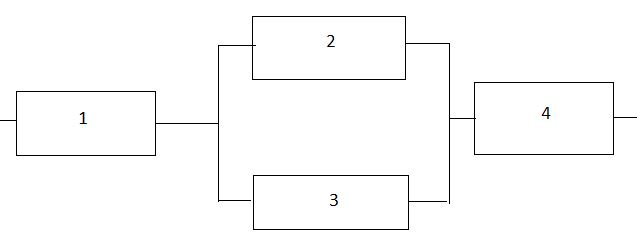

Układ sortowni

Przyjmijmy, że $1$ oznacza urządzenie składujące ubrania do sortowania i wpuszczające je na hale, w przypadku gdy będzie niesprawne, żadne ubrania nie zostaną wprowadzone, a więc i posortowane co spowoduje chwilowe zamknięcie sortowni. Z kolei $2$ oraz $3$ są oznaczeniem dla sortowników, działają równolegle, więc gdy jeden z nich ulegnie uszkodzeniu, drugi wciąż może pracować i sortownia w dalszym ciągu będzie działać. Natomiast gdy obydwa zepsują się jednocześnie to również spowoduje to zatrzymaniu prac. Ostatnim elementem jest $4$, która reprezentuje urządzenie składujące posortowane ubrania i wyprowadzające je z hali, również jest kluczowe bo jego zatrzymanie spowoduje zaprzestanie dostarczania posortowanych ubrań. Każde z tych urządzeń ma pewien swój “czas życia”, który można zamodelować korzystając z odpowiednich rozkładów, a konkretniej mówiąc:

1. urządzenie $1 \sim weibull(30,3)$,
2. urządzenie $2 \sim exp(0.05)$,
3. urządzenie $3 \sim exp(0.1)$,
4. urządzenie $4 \sim weibull(50,2)$.

Oznaczmy każdemu elementowi zmienną binarną $x_i$, gdzie $i \in \{1,2,3,4\}$ oznacza numer elementu, $x_i = 1$, gdy element jest zdatny oraz $x_i = 0$ gdy $i$-ty element jest niezdatny. Stworzymy też tzw. funkcje struktury $\phi(x) = x_1 \cdot ... \cdot x_n$ dla układów szeregowych oraz $\phi(x) = 1 - (1-x_1)\cdot...\cdot(1-x_n)$ dla układów równoległych, gdzie w naszym przypadku elementy $1$ jest połączony szeregowo z elementami $(2,3)$ oraz $4$, analogicznie $4$, natomiast elementy $(2,3)$ są połączone ze sobą równolegle, a ich połączenie równoległe jest połączeniem szeregowym z pozostałymi. Mówimy, że system jest zdatny, gdy $\phi(x)=1$ oraz niezdatny, gdy $\phi(x)=0$. Zatem w naszym przypadku mamy
$$\phi(x) = x_1 \cdot (1 - (1-x_2)\cdot(1-x_3)) \cdot x_4 = x_1 \cdot (1 - 1 + x_3 +x_2 -x_2x_3) \cdot x_4 = x_1 \cdot (x_2 + x_3 - x_2x_3)\cdot x_4.$$
Teraz oznaczmy przez $p_i = P(x_i = 1) = E(x_i)$, czyli jest to prawdopodobieństwo zdatności $i$-tego elementu w danej chwili. Uwzględniając niezależność naszych elementów możemy rozpisać niezawodność teoretyczną systemu następująco
$$E(\phi(x)) = p_1 \cdot ( p_2 + p_3 - p_2p_3)\cdot p_4.$$
W celu dokonania symulacji czasu działania takiej sortowni dokonamy symulacji poprzez losowanie z zaimplementowanych przez nas generatorów oraz w celu sprawdzenia dokonamy także przeliczenia niezawodności teoretycznej wykorzystując wbudowane funkcje w programie R. Implementacja tego jest następująca.

```r
#---------------SYMULACJA CZASU DZIALANIA UKLADU------------------------
#Niezawodnosc teoretyczna
r <- function(t){
  p1 = 1-pweibull(t,shape=3,scale=30)
  p2 = 1-pexp(t,0.05)
  p3 = 1-pexp(t,0.1)
  p4 = 1-pweibull(t,shape=2,scale=50)

  p1*(p2 + p3 - p2*p3)*p4
}

symulacja<-function(n){
  z <- c()
  x1 <- weibull_rand(N=n, theta=30,k=3, mode="implemented")
  x2 <- exp_rand(N=n, theta=0.05, mode="implemented")
  x3 <- exp_rand(N=n, theta=0.1, mode="implemented")
  x4 <- weibull_rand(N=n, theta=50,k=2, mode="implemented")

  w <- c()
  wx1 <- rweibull(n,shape=3,scale=30)
  wx2 <- rexp(n,0.05)
  wx3 <- rexp(n,0.1)
  wx4 <- rweibull(n,shape=2,scale=50)


  for(i in 1:n){
    z[i]<- min(x1[i], max(x2[i],x3[i]),x4[i])
    w[i]<- min(wx1[i], max(wx2[i],wx3[i]),wx4[i])
  }

  #Srednia teoretyczna:
  teor <- integrate(r,0,Inf)
  print("Średnia teoretyczna: ")
  print(teor)
  #Z symulacji:
  print("Średnia wartość empiryczna z generatorów własnych: ")
  print(mean(z))
  print("Średnia wartość empiryczna z generatorów wbudowanych: ")
  print(mean(w))
  hist(z, main='Histogram czasu zycia', ylab='czestotliwosc')

}
```

```r
symulacja(100)
```

```
## [1] "Średnia teoretyczna: "
## 15.55242 with absolute error < 1.2e-07
## [1] "Średnia wartość empiryczna z generatorów własnych: "
## [1] 15.72205
## [1] "Średnia wartość empiryczna z generatorów wbudowanych: "
## [1] 15.23758
```

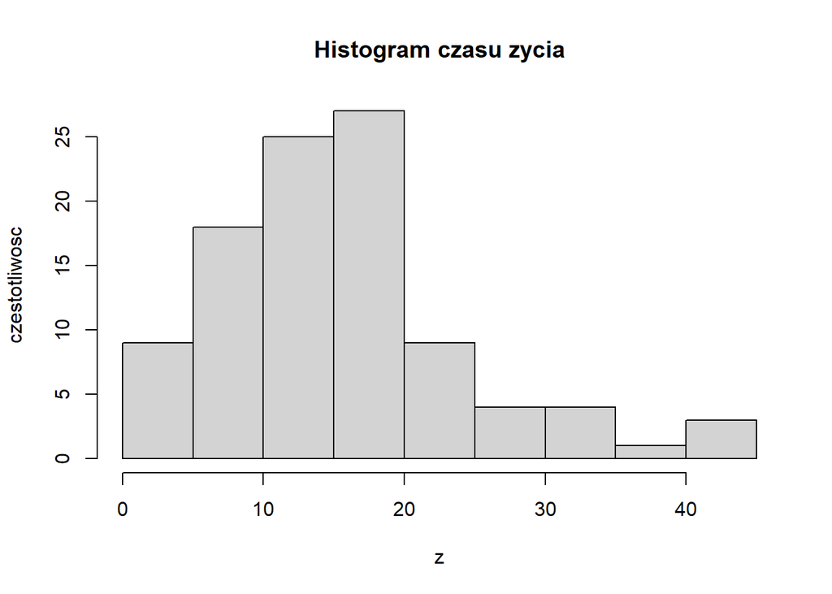

Oraz dla bardziej liczebnej symulacji $n=10000$.

```r
symulacja(10000)
```

```
## [1] "Średnia teoretyczna: "
## 15.55242 with absolute error < 1.2e-07
## [1] "Średnia wartość empiryczna z generatorów własnych: "
## [1] 15.62592
## [1] "Średnia wartość empiryczna z generatorów wbudowanych: "
## [1] 15.61245
```

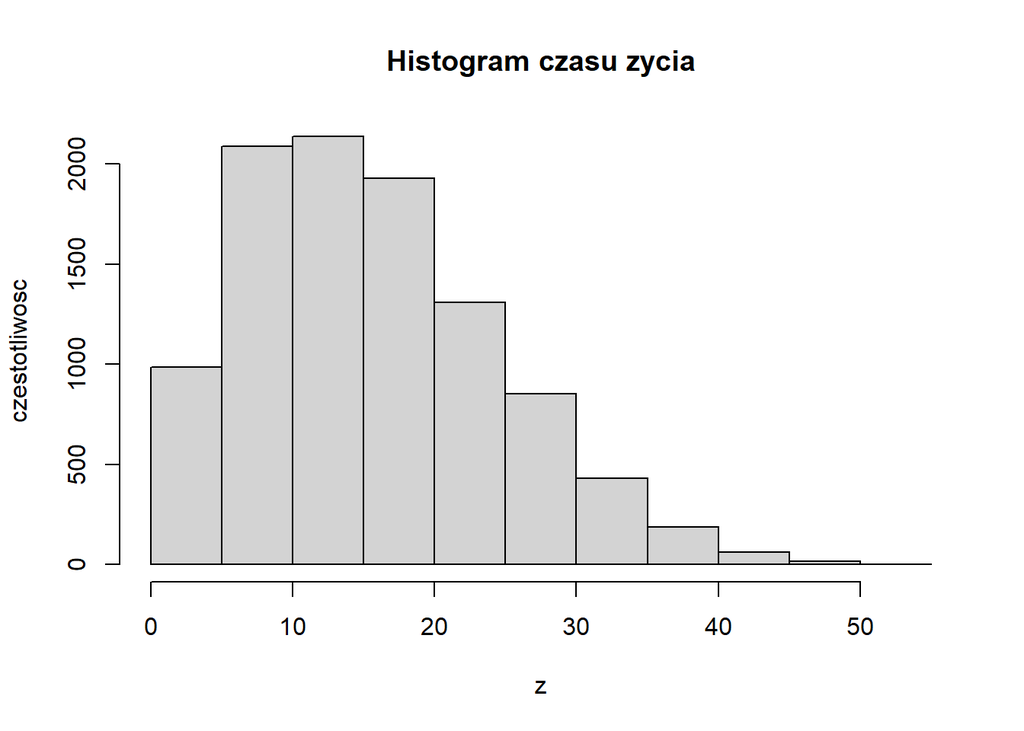

Wartości teoretyczne oczywiście nie ulegają zmianom, ale pewne jest że liczebniejsza próbka oferuje większą stabilność modelu. Jak widać, zarówno przy pomocy generatorów własnych, jak też wbudowanych, uzyskane zostały wyniki bliskie teoretycznemu. Właśnie wyliczyliśmy teoretyczną średnią wartość czasu pracy sortowni, czyli ok. 15 dni. Dodatkowo, przygotowaliśmy symulację korzystając z generatorów liczb pseudolosowych z rozkładu wykładniczego i Weibulla (własnych jak i wbudowanych) przez którą pokazaliśmy słuszność wyniku teoretycznego. Ponadto jesteśmy w stanie dokonać wizualizacji przy pomocy histogramu, średniego czasu zdatności sortowni o takich urządzeniach, których czas pracy można wyrazić korzystając z owych rozkładów.

## 2.9 Podsumowanie

W tym raporcie wprowadzona została powierzchowna teoria dotycząca tworzeniu generatorów liczb pseudolosowych pochodzących z rozkładów takich jak rozkład wykładniczy, Weibulla, arcusa sinusa, normalny (dwoma metodami) oraz Poissona przy użyciu generatora liczb z rozkładu jednostajnego. Tutaj wzięliśmy zarówno własny generator liniowej kongruencji, jak również w dalszych rozważaniach, w celu ujednolicenia, generator wbudowany. Pokazaliśmy raz jeszcze istotność założeń generatora liniowej kongruencji i ich wpływ na wyniki przy poszczególnych, innych rozkładach. Większa część opierała się na metodzie transformacji odwrotnej, aczkolwiek też była część polegająca na przeprowadzeniu testu odrzucającego. Co więcej, zaprezentowany został także algorytm Boxa Mullera oraz metoda podwójna wykładnicza do generowania liczb ze standardowego rozkładu normalnego. Na końcu wykorzystano zbudowane generatory wykładnicze i Weibulla do wykonania zadania symulacji średniego czasu zdatności pewnej sortowni, którą pokrótce opisano we wstępie.

# 3 Modelowanie wielkości roszczeń ubezpieczeniowych rozkładem Gamma

## 3.1 Wprowadzenie

W pracy przedstawione zostanie pokrótce teoretyczne podejście do tematu generowanie liczb z rozkładu Gamma, a następnie zaimplementowane zostaną dwa generatory z tego rozkładu. Pierwszym z nich będzie generator stworzony przy pomocy algorytmu GKM1, natomiast drugi będzie opierał się na algorytmie Ahrensa-Dietera. Porównane zostaną czasy, jak też średnie liczby iteracji z obu implementacji.

Przytoczony zostanie także generator liczb z rozkładu Poissona stworzony w ramach ostatniego projektu z lekką modyfikacją wykluczającą możliwość wykorzystania własnego generatora liczb z rozkładu jednostajnego z racji skorzystania z generatora wbudowanego. Później zamodelowany zostanie proces roszczeń ubezpieczeniowych z wykorzystaniem wyżej wspomnianego generatora, jak też zaimplementowanego generatora liczb z rozkładu Gamma.

## 3.2 Rozkład Gamma

Rozkład Gamma z parametrem kształtu $a$ oraz skali $\beta$ ma gestość równą
$$f(y) = f_{a, \beta}(y) = \frac{1}{\Gamma (a)\beta^a}y^{a-1}e^{-y/\beta}, \quad y\geq 0$$
Taki rozkład posiada średnią równią $a\beta$ oraz wariancję $a\beta^2$. Metody próbkowania z rozkładu Gamma możemy rozróżnić na te uwzględniające sytuację dla $a \leq 1$ oraz $a > 1$. W przypadku wykorzystania generatora do modelowania stóp procentowych w większości przypadków spotkamy sytuację z $a>1$, natomiast uwzględniona zostanie także sytuacja dla $a \leq 1$. Nie ma natomiast straty ogólności przy założeniu $\beta = 1$, ponieważ jeśli $X$ ma rozkład Gamma z parametrami $(a,1)$ to $\beta X$ ma rozkład Gamma z parametrami $(a, \beta)$.

Stworzymy także funkcję do wykreślania gęstości.

```r
plot_hist <- function(X){
  if( typeof(X) == "list"){
    S <- unlist(X[1])
    iters <- unlist(X[2])
    title = "Histogram X - generator zaimplementowany"
    txt = "Generator zaimplementowany"
    print(paste("Liczba iteracji: ",iters, sep=""))
  } else {
    S <- X
    title = "Histogram X - generator wbudowany"
    txt = "Generator wbudowany"
  }
  hist(S, prob=TRUE, col="grey", xlab = "X", main = title)
  lines(density(S), col="blue", lwd=2)
  print(paste(txt, " średnia: ", mean(S), sep=""))
  print(paste(txt, " wariancja: ", var(S), sep=""))

}
```

## 3.3 Algorytm GKM1

Przypuśćmy, że pewna funkcja $f$ jest nieujemna oraz całkowalna na zbiorze $[0, \infty)$. Jeżeli $(X,Y)$ ma rozkład jednostajny na zbiorze $A = \{(x,y): x \leq \sqrt{f(y/x)}\}$ to wówczas gęstość $Y/X$ jest proporcjonalna do $f$. Zatem, aby jednostajnie próbkować z $A$ możemy powtarzalnie, jednostajnie wybierać pary $(X,Y)$ z prostokąta i zachowywać pierwsze, dla których $X \leq \sqrt{f(Y/X)}$. W celu próbkowania z gęstości Gamma z parametrem $a > 1$ zdefiniujemy zbiór $A$, tj.
$$A = \{(x,y): 0\leq x \leq \sqrt{[(y/x)^{a-1}e^{-y/x}}\}$$
Ten zbiór jest zawarty w prostokącie $[0,\overline{x}] \times [0,\overline{y}]$ gdzie $\overline{x} = [(a-1)/e]^{(a-1)/2}$. Próbkując jednostajnie z tego prostokąta oczekiwana liczba próbek potrzebna do czasu wypadnięcia w $A$ jest określona przez proporcję wymiaru $A$ do wymiaru tego prostokąta. Określone jest przez $O(\sqrt{a})$, więc czas potrzebny do wygenerowania próbki tą metodą wzrasta wraz z parametrem kształtu. W algorytmie GKM1 mamy w pierwszej kolejności wykonany test akceptacji, który zmniejsza liczbę przekształceń logarytmicznych. Poniżej znajduje się zaimplementowany algorytm.

```r
gkm1 <- function(a, beta, N){
  if(a <= 1){
    return("Niewłaściwy parametr a!")
  } else {
    ap <- a-1
    b <- (a-(1/(6*a)))/ap
    m <- 2/ap
    d <- m+2

    niter <- 0
    X <- c()

    while(length(X) < N){
      sample <- "Reject"
      while(sample != "Accept"){
        niter <- niter + 1
        U1 <- runif(1)
        U2 <- runif(1)
        V <- b*U2/U1

        check1 <- m*U1 - d + V + (1/V)
        check2 <- m*log(U1) - log(V) + V - 1

        if(check1 <= 0){
          sample <- "Accept"
        } else if(check2 <= 0){
          sample <- "Accept"
        } else {
          sample <- "Reject"
        }
      }
    X <- append(X, beta*ap*V)
    }
  }

  return(list(X, niter))
}
```

## 3.4 Algorytm Ahrensa-Dietera

Algorytm Ahrensa-Dietera obsługuje przypadek, gdy $a \leq 1$. Generowani są “kandydaci” poprzez próbkowanie z rozkładów skoncentrowanych na przedziałach $[0,1]$ oraz $(1, \infty)$ z odpowiednimi prawdopodobieństwami. W szczególności niech $p = e/(a + e)$ oraz
$$g(z) = \left\{ \begin{array}{ll} paz^{a-1}, & 0 \leq z \leq 0\\
(1-p)e^{-z+1}, & z > 1.\end{array} \right.$$
Jest to gętość, która jest “mieszanką” gęstości $az^{a-1}$ na $[0,1]$ oraz $e^{-z+1}$ na $(1,\infty)$ z odpowiednimi wagami $p$ i $(1-p)$. Możemy próbkować z $g$ poprzez próbkowanie z każdej z tych gęstości z przypisanym prawdopodobieństwem. Każda z tych dwóch gęstości jest łatwo próbkowana przy wykorzystaniu metody odwrotnej transformaty tj. dla gęstości $az^{a-1}$ możemy wykorzystać $U^{1/a}$, gdzie $U \sim Unif[0,1]$ oraz dla gęstości $e^{-z+1}$ mamy $1-log(U)$. Próbki z $g$ są odpowiednimi kandydatami dla metody “accept-rejection” ponieważ proporcja $f_{a,1}(z)/g(z)$ z $f_{a,1}$ gęstością Gamma jest ograniczona. Wgląd w tą proporcję nasuwa, że kandydat $Z$ na przedziale $[0,1]$ jest akceptowany z prawdopodobieństwem $e^{-Z}$, a kandydat na $(1, \infty)$ jest akceptowany z prawdopodobieństwem $Z^{a-1}$. Globalne ograniczenie proporcji dane jest poprzez
$$f_{a,1}(z) / g(z) \leq \frac{a+e}{ae\Gamma(a)} \leq 1.39,$$
gdzie warto przypomnieć, iż górna granica ograniczenia takiej proporcji określa oczekiwaną liczbę kandydatów wygenerowanych przy akceptowanej próbce. W poniższym algorytmie warto zwrócić uwagę na fakt, że gdy warunek $Y\leq 1$ zawodzi to wówczas $Y$ ma rozkład jednostajny na $[1,b]$ co oznacza, że $(b-Y)/a$ ma rozkład $U/e$ ($U \sim Unif[0,1]$), a więc $-log((b-Y)/a)$ ma rozkład $1-log(U)$.

```r
adr <- function(a, beta, N){
  if(a > 1){
    return("Niewłaściwy parametr a!")
  } else {
    b <- (a + exp(1))/exp(1)

    niter <- 0
    X <- c()

    while(length(X) < N){
      sample <- "Reject"
      while(sample != "Accept"){
        niter <- niter + 1
        U1 <- runif(1)
        U2 <- runif(1)
        Y <- b*U1

        if (Y <= 1){
          Z <- Y^(1/a)
          if (U2 < exp(-Z)){
            sample <- "Accept"
          }
        } else {
          Z <- -log((b-Y)/a)
          if (U2 <= Z^(a-1)){
            sample <- "Accept"
          }
        }
      }
    X <- append(X, beta*Z)
    }
  }

  return(list(X, niter))
}
```

## 3.5 Testowanie

Po implementacji obu algorytmów przygotujemy funkcję, która będzie pozwalała na swobodne korzystanie z generatora liczb z rozkładu Gamma zależnie od przyjętego parametru kształtu $a$.

```r
gam <- function(a, beta, N, unlist=FALSE){
  if (a <= 1){
    G <- adr(a,beta,N)
  } else {
    G <- gkm1(a, beta, N)
  }

  if (unlist){
    G <- unlist(G[1])
  }
  return(G)
}
```

Zacznijmy od przypadku $a <= 1$ i wykreślmy histogram z przyrównaniem do próbki wygenerowanej z generatora wbudowanego. Niech $a = 1$ oraz $\beta = 2$ dla próbki $N=1000$.

```
## [1] "Liczba iteracji: 1337"
```

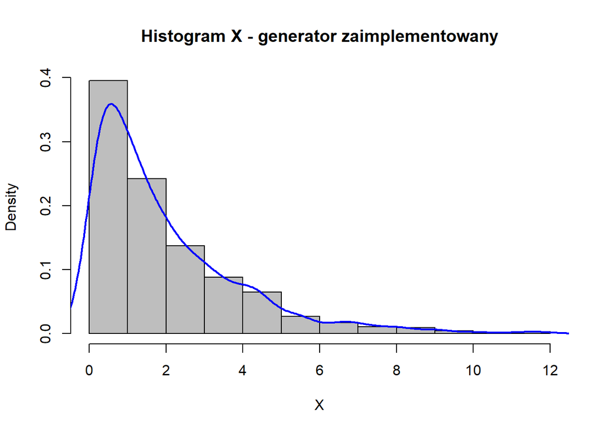

```
## [1] "Generator zaimplementowany średnia: 1.96627969203212"
## [1] "Generator zaimplementowany wariancja: 3.67350344023736"
```

```r
G1 <- gam(1,2,1000)
G2 <- rgamma(n=1000, scale=2, shape=1)
plot_hist(G1)
```

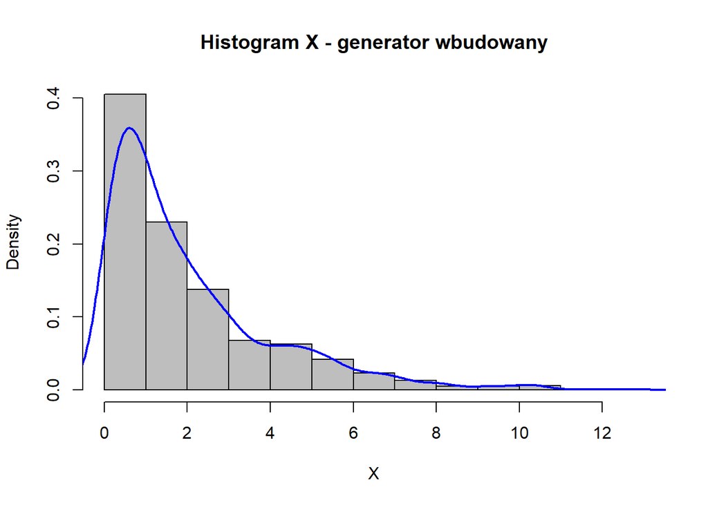

```
## [1] "Generator wbudowany średnia: 2.03880115191768"
## [1] "Generator wbudowany wariancja: 4.11941907254965"
```

```r
plot_hist(G2)
```

Możemy bez problemu dostrzec zbieżność obydwu próbek. Sprawdźmy, więc sytuację dla parametrów $a = 0.5$ oraz $\beta = 1$.

```
## [1] "Liczba iteracji: 1367"
```

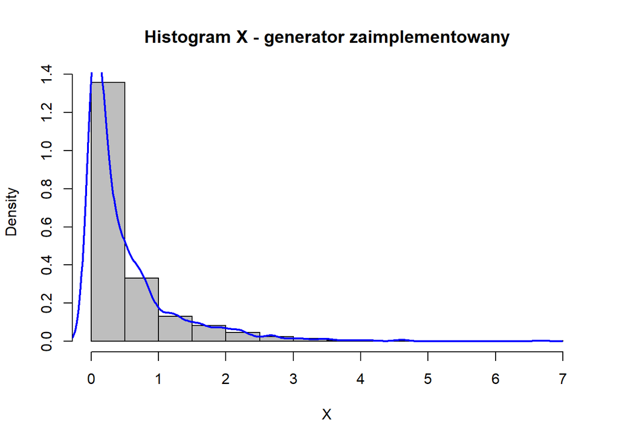

```
## [1] "Generator zaimplementowany średnia: 0.511649464298375"
## [1] "Generator zaimplementowany wariancja: 0.508303099558069"
```

```r
G1 <- gam(0.5,1,1000)
G2 <- rgamma(n=1000, scale=1, shape=0.5)
plot_hist(G1)
```

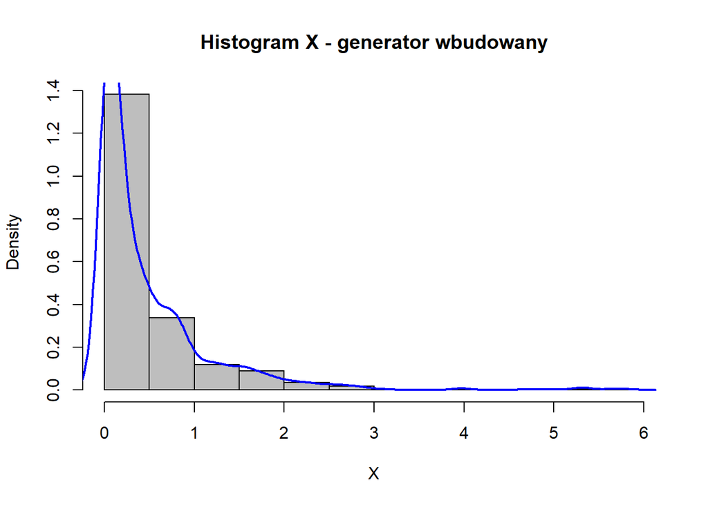

```
## [1] "Generator wbudowany średnia: 0.483056851486767"
## [1] "Generator wbudowany wariancja: 0.502948790655215"
```

```r
plot_hist(G2)
```

Ponownie histogramy są do siebie zbliżone. Świadczy to o poprawności zaimplementowanego algorytmu oraz osiąganiu poprawnych wyników próbki dla przypadku $a<=1$. Co więcej, ukazuje to faktyczny brak straty ogólności przy zakładaniu $\beta =1$ podczas implementacji i przemnożeniu przez ten czynnik w końcowym etapie. Zobaczmy sytuację dla $a>1$, więc weźmy pod uwagę $a = 2$ oraz $\beta = 2$.

```
## [1] "Liczba iteracji: 1359"
```

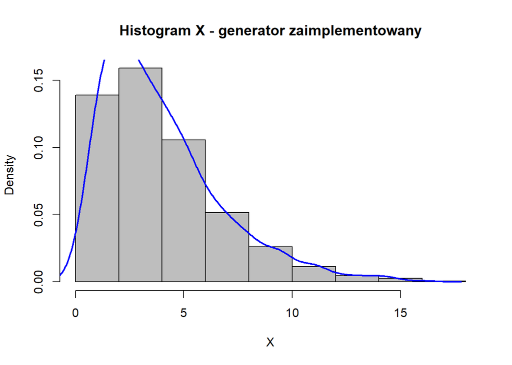

```
## [1] "Generator zaimplementowany średnia: 3.9617106154839"
## [1] "Generator zaimplementowany wariancja: 7.5217722508913"
```

```r
G1 <- gam(2,2,1000)
G2 <- rgamma(n=1000, scale=2, shape=2)
plot_hist(G1)
```

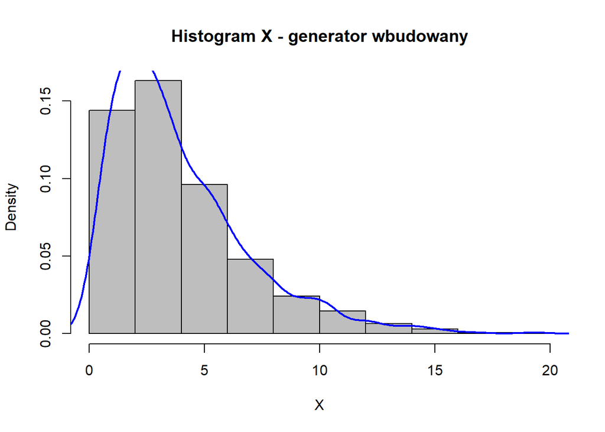

```
## [1] "Generator wbudowany średnia: 3.91083177468001"
## [1] "Generator wbudowany wariancja: 8.53601345352626"
```

```r
plot_hist(G2)
```

Ponownie zgodnie z oczekiwaniami również otrzymujemy zbieżności obydwu histogramów. Rozpatrzmy jeszcze $a = 9$ oraz $\beta = 0.5$.

```
## [1] "Liczba iteracji: 2484"
```

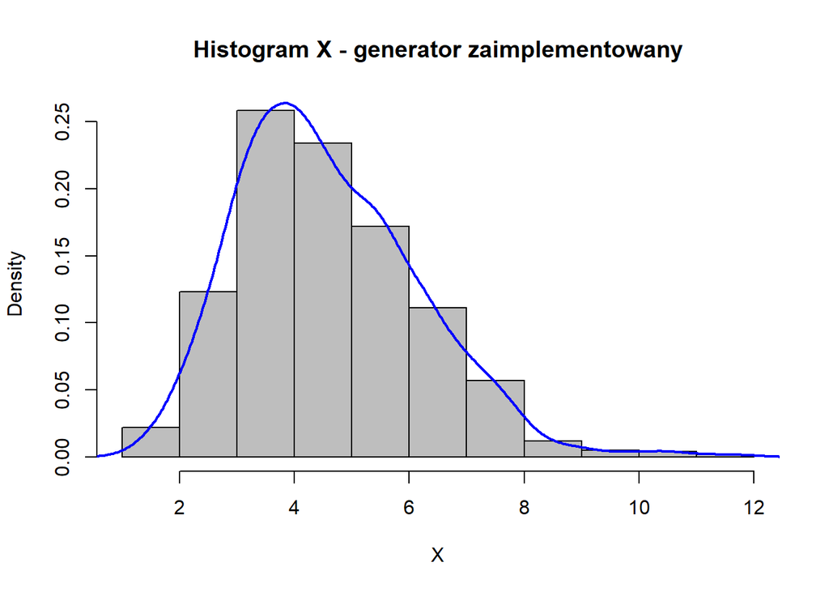

```
## [1] "Generator zaimplementowany średnia: 4.59450432202359"
## [1] "Generator zaimplementowany wariancja: 2.52803351136898"
```

```r
G1 <- gam(9,0.5,1000)
G2 <- rgamma(n=1000, scale=0.5, shape=9)
plot_hist(G1)
```

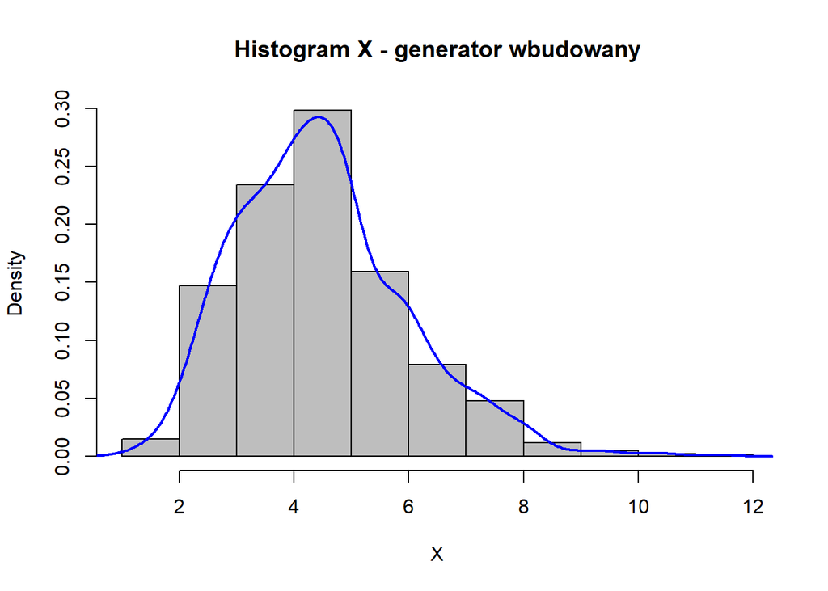

```
## [1] "Generator wbudowany średnia: 4.47507831227343"
## [1] "Generator wbudowany wariancja: 2.20092244001616"
```

```r
plot_hist(G2)
```

Rzeczywiście w dalszym ciągu wartości są zbliżone. Co więcej, oprócz wizualnego porównania możemy dostrzec, iż mimo niewielkich odchyleń, wartości statystyk (średniej i wariancji) są sobie bliskie. Wnioskujemy po tym, iż zaimplementowany algorytm generowanie próbki z rozkładu Gamma jest poprawny.

Kolejną rzeczą, którą sprawdzimy jest czas i liczba potrzebnych iteracji do wygenerowania próbki w zależności od przyjętego parametru $a$, jako że korzystamy wówczas z innych algorytmów. W pierwszej kolejności sprawdźmy dla $N \in \{100, 1000, 5000, 10000, 20000\}$ przy $a = 0.5$ jako $a <=1$ (więc algorytm Ahrensa-Dietera) oraz $a=2$ jako $a>1$ (algorytm GKM1).

```r
iters1 <- c()
time1 <- c()
iters2 <- c()
time2 <- c()
x <- c()
N <- c()
for (n in c(100, 1000, 5000, 10000, 20000)){
  N <- append(N, n)

  start.time <- as.numeric(as.numeric(Sys.time())*1000, digits=15)
  G1 <- gam(0.5, 2, N=n)
  end.time <-  as.numeric(as.numeric(Sys.time())*1000, digits=15)
  t1 <- end.time - start.time


  iters1 <- append(iters1, unlist(G1[2]))
  time1 <- append(time1, t1)

  start.time <- as.numeric(as.numeric(Sys.time())*1000, digits=15)
  G2 <- gam(2, 2, N=n)
  end.time <-  as.numeric(as.numeric(Sys.time())*1000, digits=15)
  t2 <- end.time - start.time


  iters2 <- append(iters2, unlist(G2[2]))
  time2 <- append(time2, t2)

  print(paste("Liczba iteracji dla a <=1: ", unlist(G1[2]), " przy N=", n,sep=""))
  print(paste("Liczba iteracji a >1: ", unlist(G2[2]), " przy N=", n, sep=""))

  print(paste("Czas wykonania algorytmu dla a <=1: ", t1, " przy N=", n,sep=""))
  print(paste("Czas wykonania algorytmu a >1: ", t2, " przy N=", n, sep=""))

}
```

```
## [1] "Liczba iteracji dla a <=1: 133 przy N=100"
## [1] "Liczba iteracji a >1: 143 przy N=100"
## [1] "Czas wykonania algorytmu dla a <=1: 0.98291015625 przy N=100"
## [1] "Czas wykonania algorytmu a >1: 1.015869140625 przy N=100"
## [1] "Liczba iteracji dla a <=1: 1335 przy N=1000"
## [1] "Liczba iteracji a >1: 1396 przy N=1000"
## [1] "Czas wykonania algorytmu dla a <=1: 8.99609375 przy N=1000"
## [1] "Czas wykonania algorytmu a >1: 10.97802734375 przy N=1000"
## [1] "Liczba iteracji dla a <=1: 6730 przy N=5000"
## [1] "Liczba iteracji a >1: 7042 przy N=5000"
## [1] "Czas wykonania algorytmu dla a <=1: 143.144775390625 przy N=5000"
## [1] "Czas wykonania algorytmu a >1: 148.900146484375 przy N=5000"
## [1] "Liczba iteracji dla a <=1: 13420 przy N=10000"
## [1] "Liczba iteracji a >1: 14094 przy N=10000"
## [1] "Czas wykonania algorytmu dla a <=1: 353.01611328125 przy N=10000"
## [1] "Czas wykonania algorytmu a >1: 264.69091796875 przy N=10000"
## [1] "Liczba iteracji dla a <=1: 26626 przy N=20000"
## [1] "Liczba iteracji a >1: 28126 przy N=20000"
## [1] "Czas wykonania algorytmu dla a <=1: 874.69091796875 przy N=20000"
## [1] "Czas wykonania algorytmu a >1: 1075.64306640625 przy N=20000"
```

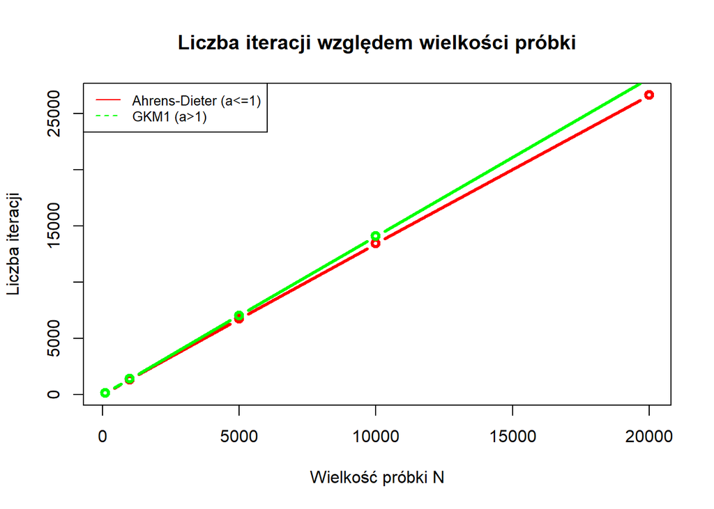

```r
plot(N, iters1,  type = "b", col = "red" , lwd = 3, pch = 1, xlab="", ylab="")
lines(N, iters2, type = "b", col = "green" , lwd = 3, pch = 1)
title(main = "Liczba iteracji względem wielkości próbki", xlab = "Wielkość próbki N", ylab="Liczba iteracji")
legend("topleft", legend=c("Ahrens-Dieter (a<=1)", "GKM1 (a>1)"), col=c("red","green"),lty=1:2, cex=0.8)
```

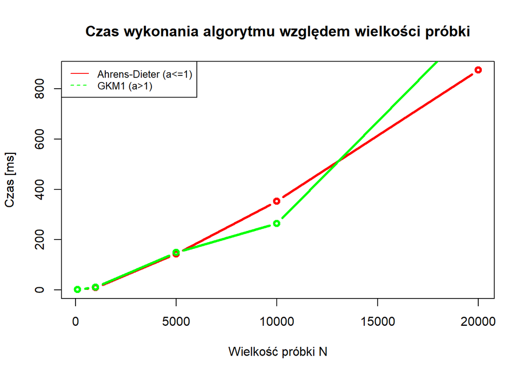

```r
plot(N, time1,  type = "b", col = "red" , lwd = 3, pch = 1, xlab="", ylab="")
lines(N, time2, type = "b", col = "green" , lwd = 3, pch = 1)
title(main = "Czas wykonania algorytmu względem wielkości próbki", xlab = "Wielkość próbki N", ylab="Czas [ms]")
legend("topleft", legend=c("Ahrens-Dieter (a<=1)", "GKM1 (a>1)"), col=c("red","green"),lty=1:2, cex=0.8)
```

## 3.6 Modelowanie procesu roszczeń ubezpieczeniowych

W celu zamodelowania procesu roszczeń ubezpieczeniowych posłużymy się zaimplementowanym generatorem z rozkładu Gamma oraz lekko zmienionym generatorem z rozkładu Poissona z poprzedniej części projektu, tj.

```r
poisson <- function(N,theta){
    X <- c()
    while(length(X) < N){
      p <- exp(-theta)
      Fd <- p
      Nbig <- 0


      U <- runif(2)
      U1 <- U[2]

      while (U1 > Fd){
        Nbig <- Nbig + 1
        p <- p*theta/Nbig
        Fd <- Fd + p
        }
      X <- append(X,Nbig)
      }
    return(X)
}
```

W tym rozdziale zamodelujemy proces roszczeń ubezpieczeniowych poprzez zbudowanie modelu probabilistycznego, który opisze nam proces pojawiania się zagregowanych roszczeń ubezpieczeniowych w pewnym okresie czasowym. Taki system ubezpieczeniowy może być złożony z pojedynczej polisy czy też grupy kontraktów ubezpieczeniowych. Zagregowane roszczenia są sumą wszystkich roszczeń zaboserwowanych w pewnym okresie. Możemy wyróżnić wówczas model indywidualnego ryzyka, w którym rozważa się stratę z każdego indywidualnego kontraktu bądź model ryzyka zbiorowego, który modeluje podejścia rozważające rozkład częstości, jak też surowości roszczeń. Można go przedstawić jako
$$S_N = X_1 + X_2 +... + X_N,$$
gdzie $N$ jest zmienną losową oznaczającą liczbę strat (lub liczbę wypłat). Naturalnie możemy założyć $X_i>0$, ponieważ gdy $X_i = 0$ to nie mamy roszczenia. Zakładamy, że $N=n, X_1, X_2, ..., X_n$ są niezależnymi zmiennymi losowymi o jednakowych rozkładach.

Rozkład $N$ znany jest jako rozkład częstości. W naszym przypadku skorzystamy z rozkładu Poissona, który jest jednym ze znanych rozkładów dyskretnych (oprócz tego popularny jest rozkład dwumianowy oraz dwumianowy ujemny). Jak wiadomo, rozkład ten możemy traktować jako rozkład liczący ilość wystąpień jakiegoś zdarzenia losowego w określonej jednostce czasu, a więc także liczący ilość wystąpień roszczeń ubezpieczeniowych w danym okresie.

Z kolei wspólny rozkład $X$ znany jest jako rozkład surowości. Jako, że podchodzimy do modelu procesu roszczeń ubezpieczeniowych poprzez model ryzyka zbiorowego to opieramy się na oddzielnym modelowaniu częstości i wysokości roszczeń. W takiej sytuacji popularnym jest stosowanie, jak wyżej napisano, modelowanie częstości poprzez proces Poissona wraz z modelowaniem wysokości roszczeń rozkładem Gamma. Oprócz tego, stosuje się także rozkład Pareto czy też Weibulla.

Nasz algorytm modelu wygląda następująco:

1. Zakładamy model ryzyka zbiorowego $S_N = X_1 + ... + X_N$;
2. Niech $j = 1, ..., m$ będzie iteratorem ustawionym od $j=1$;
3. Generujemy liczbę roszczeń $n_j$ z rozkładu częstości $N$;
4. Mając wartość $n_j$ generujemy wysokość każdego z roszczeń niezależnie z rozkładu surowości $X$ oznaczonego poprzez $x_{1j}, ..., x_{n_jj}$;
5. Przeliczamy zagregowaną stratę $s_j = x_{1j} + ... + x_{n_jj}$;
6. Powtarzamy powyższe trzy kroki dla $j=2, ..., m$ otrzymując próbkę $S_N$ wielkości $m$, tj. $\{s_1, ..., s_m\}$.

Dla naszego modelu rozważamy rozkład częstości $N \sim Poiss(\lambda = 25)$ oraz rozkład wysokości roszczeń $X \sim Gamma(5, 2)$. Poniżej zaprezentowano kod symulacyjny agregowaną wysokość roszczeń.

```r
insurance_model <- function(t, lambda=25, a=5, beta=2, seed=123){
  set.seed(seed)
  S <- rep(NA,t)

  n <- poisson(t, theta=lambda)
  for (j in 1:t){
    n_j <- n[j]
    x_j <- gam(a, beta, n_j, unlist=TRUE)
    s_j <- sum(x_j)
    S[j] <- s_j
  }
  return(S)

}
```

Sprawdźmy jak kreuje się ona dla czasu $t = 12$ miesięcy przy podanych parametrach.

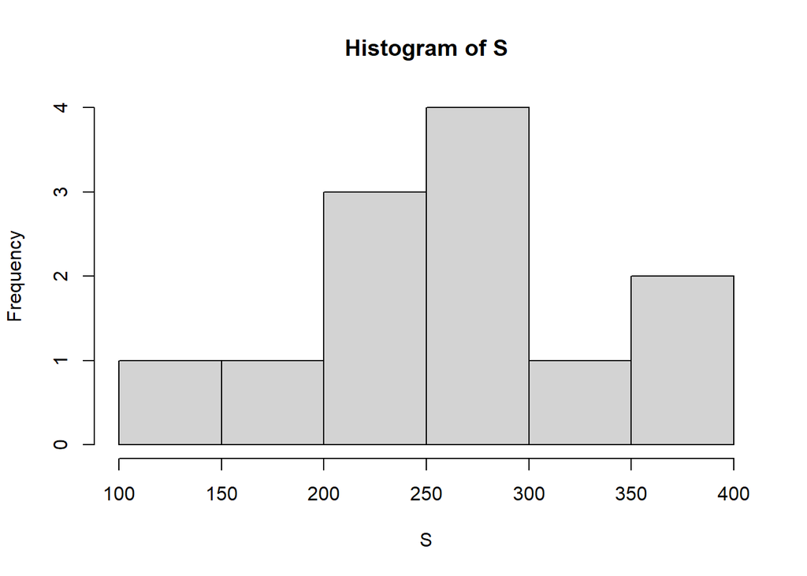

```r
S <- insurance_model(t=12)
hist(S)
```

```r
print(paste("Suma roszczeń na przedziale 12 miesięcy: ", sum(S), sep=""))
```

```
## [1] "Suma roszczeń na przedziale 12 miesięcy: 3149.08704382361"
```

Widzimy, że zamodelowana suma roszczeń przy tych parametrach wynosi odpowiednią kwotę w złotych (przypuścmy dla ułatwienia, że naszą jednostką jest złoty polski). Z kolei z histogramu możemy odczytać najczęściej występujące wysokości roszczeń. Sprawdźmy jakie jest prawdopodobieństwo, przy owych współczynnikach rozkładów częstości i wysokości roszczeń, że w czasie $t=12$ miesięcy suma roszczeń przekroczy $K=3000$ zł. Stworzymy funkcję ułatwiającą szacowanie prawdopodobieństwa dla innych układów parametrów.

```r
insurance_model_probability <- function(K, t, N = 1000, lambda=25, a=5, beta=2){
  p = 0
  for (i in 1:N){
    seed = i

    S <- insurance_model(t = t, lambda = lambda, a = a, beta = beta, seed=seed)

    if (sum(S) > K){
      p = p+1
    }
  }

  prob = p/N

  print(paste("Prawdopodobieństwo przekroczenia sumy K: ", K, " w czasie t: ", t, " wynosi: ", prob,       " dla parametrów lambda= ", lambda, " ,a= ", a, " ,beta= ", beta, ".",sep=""))

  return(c(t, K, prob))
  }
```

```r
str1 <- insurance_model_probability(K = 3000,  t=12)
```

```
## [1] "Prawdopodobieństwo przekroczenia sumy K: 3000 w czasie t: 12 wynosi: 0.475 dla parametrów lambda= 25 ,a= 5 ,beta= 2."
```

Oznacza to, że przy danych parametrach częściej stracimy mniej jak 3000 zł. Sprawdźmy jak to prawdopodobieństwo zmienia się na przedziale $[2950, 3350]$ zł ze skokiem co $100$.

```r
K <- c()
prob <- c()
for (ks in seq(2950,3350,100)){
    K <- append(K, ks)
    str1 <- insurance_model_probability(K = ks,  t=12)
    prob <- append(prob, str1[3])
}
```

```
## [1] "Prawdopodobieństwo przekroczenia sumy K: 2950 w czasie t: 12 wynosi: 0.574 dla parametrów lambda= 25 ,a= 5 ,beta= 2."
## [1] "Prawdopodobieństwo przekroczenia sumy K: 3050 w czasie t: 12 wynosi: 0.381 dla parametrów lambda= 25 ,a= 5 ,beta= 2."
## [1] "Prawdopodobieństwo przekroczenia sumy K: 3150 w czasie t: 12 wynosi: 0.205 dla parametrów lambda= 25 ,a= 5 ,beta= 2."
## [1] "Prawdopodobieństwo przekroczenia sumy K: 3250 w czasie t: 12 wynosi: 0.096 dla parametrów lambda= 25 ,a= 5 ,beta= 2."
## [1] "Prawdopodobieństwo przekroczenia sumy K: 3350 w czasie t: 12 wynosi: 0.033 dla parametrów lambda= 25 ,a= 5 ,beta= 2."
```

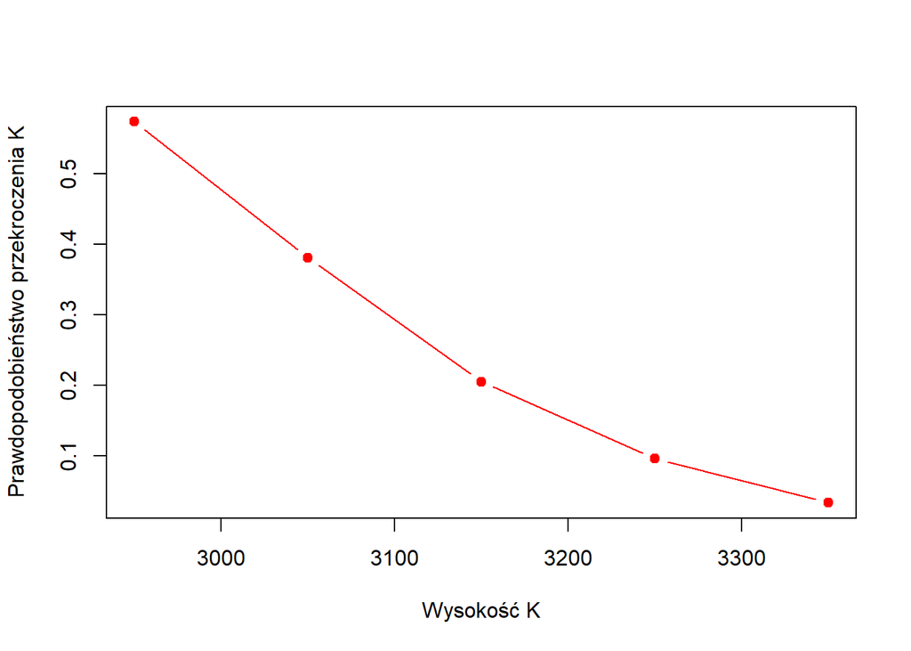

```r
plot(x= K, y=prob, type = "b", pch = 19, col="red", xlab= "Wysokość K", ylab = "Prawdopodobieństwo przekroczenia K")
```

Możemy zauważyć, że to prawdopodobieństwo dość drastycznie spada wraz ze wzrostem wysokości $K$. Zobaczmy jednak inny układ parametrów rozkładów częstości i wysokości roszczeń. Weźmy $\lambda = 15$, $a = 9$ oraz $\beta = 5$. Najpierw sprawdźmy rozkład sumy roszczeń.

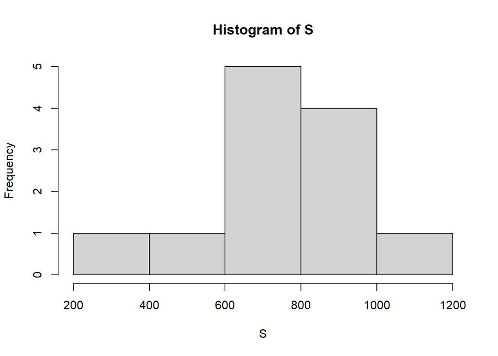

```r
S <- insurance_model(t=12, lambda = 15, a = 9, beta=5)
hist(S)
```

```r
print(paste("Suma roszczeń na przedziale 12 miesięcy: ", sum(S), sep=""))
```

```
## [1] "Suma roszczeń na przedziale 12 miesięcy: 9010.1470197877"
```

```r
K <- c()
prob <- c()
for (ks in seq(7800,8200,100)){
    K <- append(K, ks)
    str1 <- insurance_model_probability(K = ks,  t=12, lambda=15, a = 9, beta = 5)
    prob <- append(prob, str1[3])
}
```

```
## [1] "Prawdopodobieństwo przekroczenia sumy K: 7800 w czasie t: 12 wynosi: 0.659 dla parametrów lambda= 15 ,a= 9 ,beta= 5."
## [1] "Prawdopodobieństwo przekroczenia sumy K: 7900 w czasie t: 12 wynosi: 0.594 dla parametrów lambda= 15 ,a= 9 ,beta= 5."
## [1] "Prawdopodobieństwo przekroczenia sumy K: 8000 w czasie t: 12 wynosi: 0.538 dla parametrów lambda= 15 ,a= 9 ,beta= 5."
## [1] "Prawdopodobieństwo przekroczenia sumy K: 8100 w czasie t: 12 wynosi: 0.479 dla parametrów lambda= 15 ,a= 9 ,beta= 5."
## [1] "Prawdopodobieństwo przekroczenia sumy K: 8200 w czasie t: 12 wynosi: 0.415 dla parametrów lambda= 15 ,a= 9 ,beta= 5."
```

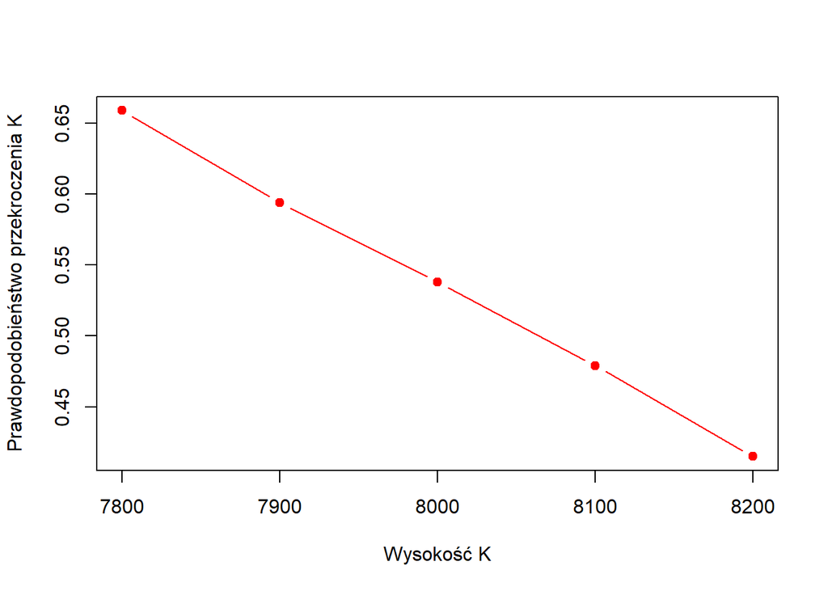

```r
plot(x= K, y=prob, type = "b", pch = 19, col="red", xlab= "Wysokość K", ylab = "Prawdopodobieństwo przekroczenia K")
```

Widzimy, że tutaj prawdopodobieństwo spada już w znacznie wolniejszym tempie. Nic dziwnego, w tym przypadku spodziewamy się średnio częstości 15 roszczeń o wyższej wartości oczekiwanej co wynika z własności rozkładów Gamma i Poissona. Na przykładzie tych dwóch zestawów parametrów sprawdźmy jeszcze wpływ okresu czasu i zmieńmy $t = 24$ miesiące czyli okres dwóch lat. W pierwszej kolejności ponownie przejrzymy rozkłady sumy roszczeń. Dla pierwszego zestawu parametrów:

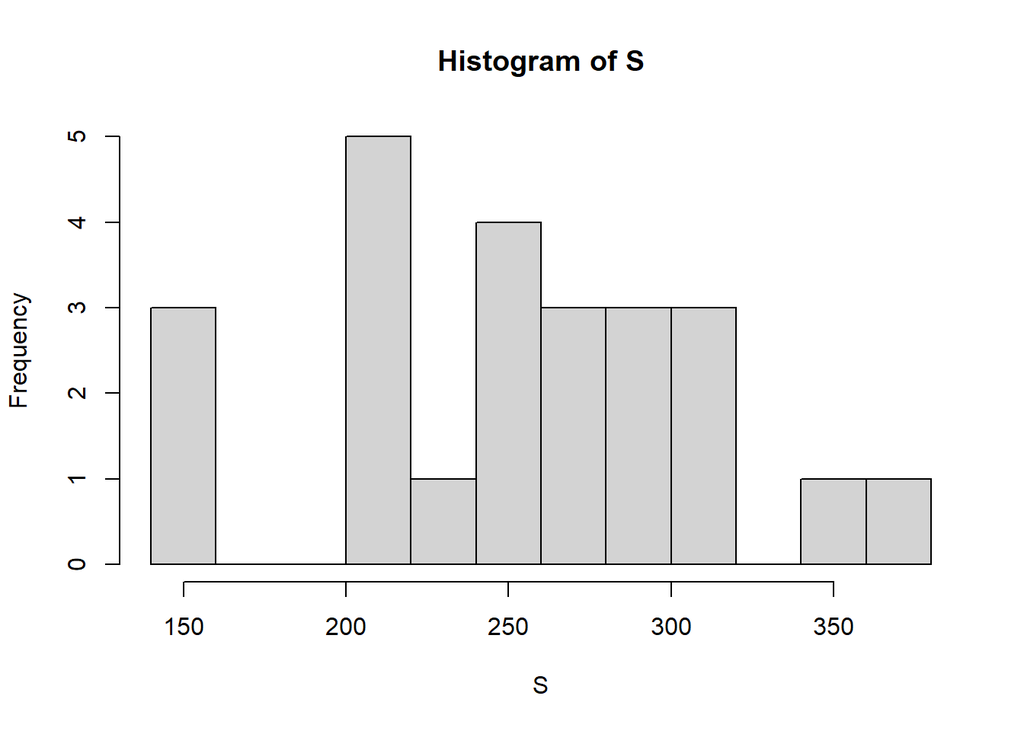

```r
S <- insurance_model(t=24)
hist(S, breaks = 15)
```

```r
print(paste("Suma roszczeń na przedziale 24 miesięcy: ", sum(S), sep=""))
```

```
## [1] "Suma roszczeń na przedziale 24 miesięcy: 6092.67062304503"
```

oraz dla drugiego zestawu:

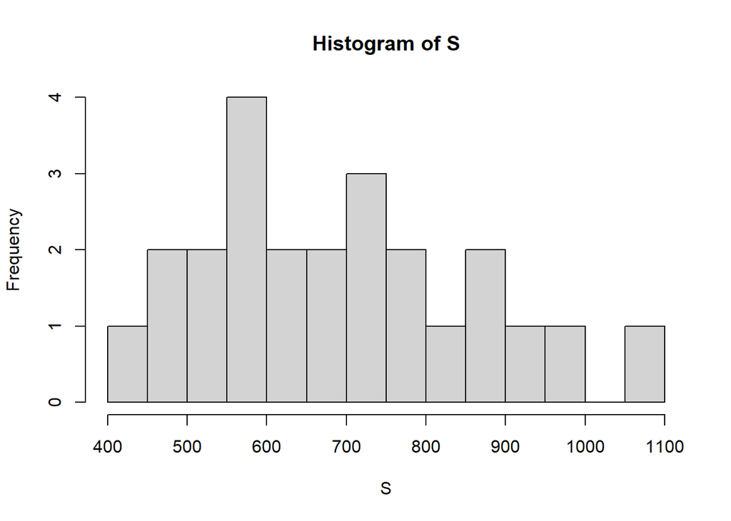

```r
S <- insurance_model(t=24, lambda = 15, a = 9, beta=5)
hist(S, breaks = 15)
```

```r
print(paste("Suma roszczeń na przedziale 24 miesięcy: ", sum(S), sep=""))
```

```
## [1] "Suma roszczeń na przedziale 24 miesięcy: 16602.6760770984"
```

Naturalnie wysokość roszczeń się zwiększyła z racji wydłużonej ilości możliwych skoków czasowych, a wzrost ten jest blisko dwukrotny tak jak wzrost okresu. Zobaczmy wpływ na prawdopodobieństwo ustawiając $K$ na przedziale $[5900, 6300]$ oraz $[16400, 16800]$ dla zestawu 1 i 2 odpowiednio.

```r
K <- c()
prob <- c()
for (ks in seq(5900,6300,100)){
    K <- append(K, ks)
    str1 <- insurance_model_probability(K = ks,  t=24)
    prob <- append(prob, str1[3])
}
```

```
## [1] "Prawdopodobieństwo przekroczenia sumy K: 5900 w czasie t: 24 wynosi: 0.607 dla parametrów lambda= 25 ,a= 5 ,beta= 2."
## [1] "Prawdopodobieństwo przekroczenia sumy K: 6000 w czasie t: 24 wynosi: 0.472 dla parametrów lambda= 25 ,a= 5 ,beta= 2."
## [1] "Prawdopodobieństwo przekroczenia sumy K: 6100 w czasie t: 24 wynosi: 0.334 dla parametrów lambda= 25 ,a= 5 ,beta= 2."
## [1] "Prawdopodobieństwo przekroczenia sumy K: 6200 w czasie t: 24 wynosi: 0.215 dla parametrów lambda= 25 ,a= 5 ,beta= 2."
## [1] "Prawdopodobieństwo przekroczenia sumy K: 6300 w czasie t: 24 wynosi: 0.132 dla parametrów lambda= 25 ,a= 5 ,beta= 2."
```

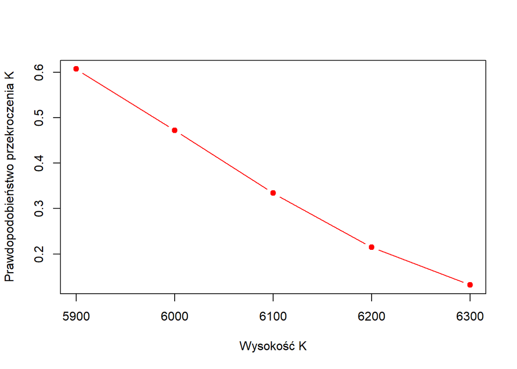

```r
plot(x= K, y=prob, type = "b", pch = 19, col="red", xlab= "Wysokość K", ylab = "Prawdopodobieństwo przekroczenia K")
```

```r
K <- c()
prob <- c()
for (ks in seq(16400,16800,100)){
    K <- append(K, ks)
    str1 <- insurance_model_probability(K = ks,  t=24, lambda=15, a = 9, beta = 5)
    prob <- append(prob, str1[3])
}
```

```
## [1] "Prawdopodobieństwo przekroczenia sumy K: 16400 w czasie t: 24 wynosi: 0.398 dla parametrów lambda= 15 ,a= 9 ,beta= 5."
## [1] "Prawdopodobieństwo przekroczenia sumy K: 16500 w czasie t: 24 wynosi: 0.353 dla parametrów lambda= 15 ,a= 9 ,beta= 5."
## [1] "Prawdopodobieństwo przekroczenia sumy K: 16600 w czasie t: 24 wynosi: 0.32 dla parametrów lambda= 15 ,a= 9 ,beta= 5."
## [1] "Prawdopodobieństwo przekroczenia sumy K: 16700 w czasie t: 24 wynosi: 0.287 dla parametrów lambda= 15 ,a= 9 ,beta= 5."
## [1] "Prawdopodobieństwo przekroczenia sumy K: 16800 w czasie t: 24 wynosi: 0.247 dla parametrów lambda= 15 ,a= 9 ,beta= 5."
```

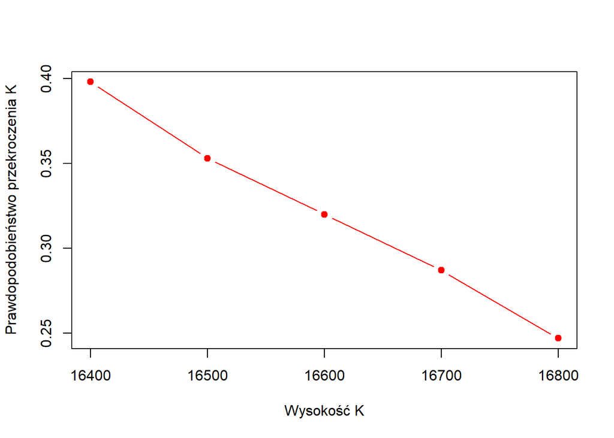

```r
plot(x= K, y=prob, type = "b", pch = 19, col="red", xlab= "Wysokość K", ylab = "Prawdopodobieństwo przekroczenia K")
```

Wnioski są analogiczne. Z racji doboru parametrów zestaw 1 ma szybciej malejące prawdopodobieństwo przekroczenia pewnej kwoty $K$ w przedziale czasowym $[0,t]$, natomiast dla zestawu 2 to prawdopodobieństwo maleje wolniej. Zwiększenie przedziału czasowego, więc nie “stabilizuje” nam prawdopodobieństwa przekroczenia pewnego poziomu straty. Dodatkowo w każdej z symulacji zostało ustawione ziarno w celu reprodukowalności wyników, jednak wcześniej przeprowadzono badanie bez tego zabiegu. Wyniki różniły się w każdej symulacji o spore ilości co wskazuje na wysoką nieprzewidywalność wysokości roszczeń. Oczywiście tutaj parametry zostały dobrane “po omacku”, jednak to właśnie odpowiedni dobór parametrów rozkładu stanowi wyzwanie dla poprawnego zamodelowania zjawiska.

## 3.7 Podsumowanie

W kolejnym projekcie zaimplementowano dwa generatory liczb z rozkładu Gamma wraz z opisem teoretycznym. Każdy z nich uwzględniał inny przypadek parametru $a$, dlatego też połączono je w jeden generator w zależności od wartości tego parametru. Co więcej, wygenerowano z nich próbki oraz zwizualizowano przyrównując do generatorów wbudowanych. Wyniki były satysfakcjonujące.

W kolejnej części przekształcono poprzednio zbudowany generator z rozkładu Poissona pod kątem stworzenia modelu procesu roszczeń ubezpieczeniowych. Rozpatrzono sumę straty (wielkości roszczeń ubezpieczeniowych) korzystając z modelu zbiorowego ryzyka przy użyciu rozkładów Poissona dla modelowania częstości oraz rozkładu Gamma dla modelowania wysokości roszczeń. Następnie rozpatrzono przykład dla różnych układów parametrów i dla każdego z nich oszacowano prawdopodobieństwo wystąpienia straty powyżej ustalonego poziomu $K$ na pewnym przedziale czasowym $[0,t]$. Wyniki te zaprezentowano w formie graficznej i poddano intepretacji.

# 4 Implementacja metody Monte Carlo dla modelu Blacka-Scholesa wyceny opcji

## 4.1 Wprowadzenie

Opcje są jednym z instrumentów finansowych, który występuje na giełdzie jak też na rynku OTC (“over-the-counter market”). Wyróżniamy dwa rodzaje opcji, pierwszą z nich jest opcja **call**, która *daje posiadaczowi opcji prawo do zakupu pewnego aktywa w określonej dacie za określoną cenę*. Drugą z nich jest opcja **put**, która z kolei *daje posiadaczowi akcji prawo do sprzedaży pewnego aktywa w określonej dacie za określoną cenę*. Cena w kontrakcie jest znana jako cena wykonania (ang. “strike price” / “excercise price”), a data zawarta w kontrakcie nazywana jest datą wygaszenia (ang. “expiration date”) lub dojrzałością (ang. “maturity”).

Co więcej, możemy rozróżnić opcje *amerykańskie* oraz opcje *europejskie*. Opcje amerykańskie można wykonać w każdym momencie, aż do daty wygaszenia. Natomiast opcje europejskie mogą zostać wykonane jedynie w momencie dojrzałości kontraktu. Oczywiście nazwy te nie odnoszą się do lokacji geograficznej.

Warto zwrócić uwagę, że opcja daje prawo posiadaczowi do wykonania pewnej czynności, jednak to prawo nie musi zostać zrealizowane. Jest to czynnik odróżniający opcje od kontraktów forward i futures, gdzie posiadacz takiego kontraktu jest zobligowany do kupna bądź sprzedaży odpowiadających aktywów. Z drugiej strony, wejście w kontrakt typu forward/futures nie wymaga wkładu pieniężnego, a zakup opcji wnosi pewne koszta (chociaż tutaj będziemy zakładać opcje bezkosztowe).

W przypadku opcji możliwe są do zauważenia pewne zależności względem ceny wykonania. Gdy cena ta wzrasta to przeważnie cena opcji call maleje, a cena opcji put rośnie. Ponadto, obydwa typy opcji mają tendencje do wzrostu wartości, gdy czas do daty wykonania wzrasta.

Na rynku opcji możemy wyróżnić cztery typy uczestników: kupiec opcji call, sprzedawca opcji call, kupiec opcji put oraz sprzedawca opcji put. Opcje są często wykorzystywane w hedgingu w celu zabezpieczenia pewnych przyjętych pozycji i dokonanych inwestycji.

## 4.2 Zysk z opcji

Oznaczmy przez $S(t)$ cenę pewnej akcji w czasie $t$. Rozważmy opcję call, która daje posiadaczowi prawo do kupna tej akcji za określoną cenę $K$ w określonym czasie przyszłym $T$. Niech $t=0$. Jeżeli w czasie $T$ wartość ceny akcji $S(T)$ przekroczy cenę wykonania $K$ to posiadacz wykorzysta opcję uzyskując zysk wysokości $S(T) - K$. Z drugiej strony, jeśli $S(T) \leq K$ to opcja nie zostanie wykonania i się przedawni (rozważamy opcję europejską, więc wykonana może zostać jedynie w czasie $T$). W takim razie zysk posiadacza opcji w czasie $T$ jest następujący
$$(S(T) - K)^{+} = \max\{0, S(T)-K\}.$$
Należy jeszcze zdyskontować tą wartość, aby uzyskać wartość aktualną tego zysku. W tym celu mnożymy całość przez czynnik dyskonta $e^{-rT}$, gdzie $r$ jest stale naliczaną stopą procentową. Wartość oczekiwana zysku wynosi, więc
$$E[e^{-rT}(S(T) - K)^{+}].$$
Aby ta wartość miała sens, musimy określić rozkład zmiennej losowej ceny akcji $S(T)$.

## 4.3 Model Blacka-Scholesa

Zamiast określać rozkład w określonym czasie, wprowadzimy model odwzorowujący dynamikę ceny akcji. Modelem opisującym ewolucję tej ceny poprzez stochastyczne równania różniczkowe (ang. “stochastic differential equations (SDE)”) jest model Blacka-Scholesa, który opisuje równanie
$$\frac{dS(T)}{S(t)} = rdt + \sigma dW(t),$$
gdzie $W$ jest standardowym ruchem Browna. To równanie może być interpretowane jako modelowanie zmiany procentowa $dS/S$ ceny akcji poprzez przyrosty ruchu Browna. Parametr $\sigma$ oznacza zmienność ceny akcji, a czynnik przy $dt$ jest średnią stopą zwrotu. W przypadku, gdy uwzględnimy średnią stopę zwrotu jako równą stopie procentowej $r$ to będziemy wprost określali neutralną pod kątem ryzyka dynamikę ceny akcji.

Rozwiązaniem tego stochastycznego równania różniczkowego, czyli równania opisującego model Blacka-Scholesa jest następujące
$$S(T) = S(0)\cdot exp([r-\frac{1}{2}\sigma^2]T + \sigma \sqrt{T}Z).$$
Logarytm ceny akcji ma więc rozkład normalny, a sama cena akcji ma rozkład log-normalny. Wartość oczekiwana $E[e^{-rT}(S(T)-K)^{+}]$ jest całką ze względu na gęstość log-normalnego rozkładu $S(T)$. Ta całka może być oszacowana poprzez dystrybuantę rozkładu normalnego $\Phi$ jako $BS(S(0),\sigma, T, r, K)$, gdzie
$$BS(S, \sigma, T, r, K) = S\Phi(\frac{\log{(S/K)} + (r+\frac{1}{2}\sigma^2)T}{\sigma\sqrt{T}}) - e^{-rT}K\Phi(\frac{\log{(S/K)} + (r-\frac{1}{2}\sigma^2)T}{\sigma\sqrt{T}}).$$
Powyższa formuła jest formułą Blacka-Scholesa dla opcji call.

## 4.4 Bieżąca wartość oczekiwana zysku z opcji europejskiej

Z równania SSD możemy zauważyć, że żeby wylosować próbkę cen akcji $S(T)$ wymagany jest mechanizm do losowania próbek ze standardowego rozkładu normalnego. Taki mechanizm zaimplementowaliśmy w poprzednim projekcie i wykorzystam go dla tego zagadnienia. Dokładniej mowa o algorytmie Boxa-Mullera tylko tym razem już dla czytelności wykorzystamy wbudowany generator liczb z rozkładu jednostajnego.

```r
normal_box <- function(N){
  X <- c()

  while(length(X) < N){

    U <- runif(2)
    U1 <- U[1]
    U2 <- U[2]
    R <- -2*log(U1)
    V <- 2*pi*U2

    Z1 <- sqrt(R)*cos(V)
    Z2 <- sqrt(R)*sin(V)


    X <- append(X,c(Z1,Z2))
    }

  return(X)
}
```

Zakładamy, więc że generujemy wektor $Z = (Z_1, Z_2, ...)$ niezależnych zmiennych losowych o normalnym rozkładzie standardowym. Mając możliwość wygenerowania $Z_i$ możemy wyestymować $E[e^{-rT}(S(T)-K)^{+}]$ poniższym algorytmem:

```r
expected_value <- function(N, s, r, K, sigma, Ti){
  # N - liczba iteracji
  # s - początkowa wartość akcji
  # r - stopa procentowa
  # sigma - zmienność cen akcji
  # Ti - czas wykonania opcji

  C <- rep(0, N)
  S <- rep(0, N)

  Z <- normal_box(N)
  for (i in 1:N){
    S[i] <- s*exp((r-1/2*sigma^2)*Ti + sigma*sqrt(Ti)*Z[i])
    C[i] <- exp(-r*Ti)*max(0, S[i] - K)
  }

  return(C)
}
```

Funkcja zwraca wektor losowy, więc wystarczy wziąć jego średnią, aby uzyskać chcianą wartość oczekiwaną. Krok ten jednak zostanie zaimplementowany w późniejszym etapie. Dla dowolnego $N\geq 1$ taki estymator wartości oczekiwanej jest nieobciążony, tj.
$$E[C_{avg}] = C \equiv E[e^{-rT}(S(T)-K)^{+}].$$
Co więcej, przy $n \rightarrow \infty$ możemy zauważyć, że $C_{avg} \rightarrow C$ z prawdopodobieństwem 1. Dla tego algorytmu możemy także zaimplementować przedział ufności estymowanej wartości oczekiwanej dla pewnego współczynnika $\alpha$. Oznaczmy odchylenie standardowe wektora $C = (C_1, ..., C_N)$ przez
$$s_C = \sqrt{\frac{1}{N-1}\sum_{i=1}^{N}{(C_i - C_{avg})^2}}.$$
Dodatkowo, niech $z_{\alpha}$ oznacza $(1-\alpha)$ kwantyl standardowego rozkładu normalnego ($\Phi(z_{\alpha}) = 1-\alpha$). Wówczas
$$C_{avg} \pm z_{\alpha/2}\frac{s_C}{\sqrt{N}}$$
jest asymptotycznie (przy $n\rightarrow \infty$) zgodne z ($1-\alpha$) przedziałem ufności dla $C$. Przykładowo dla $95$% przedziału ufności $\alpha = 0.05$ oraz $z_{\alpha/2} \approx 1.96$. Możemy zaimplementować obliczanie przedziału w następujący sposób (dla wartości $\alpha \in \{0.01, 0.05, 0.1\}$).

```r
confidence_interval <- function(alpha, C){
  # alpha - parametr ufności, alpha = 0.01, 0.05, 0.1
  # C_avg - wartość oczekiwana zysku
  # C - wektor zmiennych losowych zysku
  C_avg <- mean(C)

  if (alpha == 0.01){
    z_alpha <- 2.58
  } else if (alpha == 0.05){
    z_alpha <- 1.96
  } else if (alpha == 0.1){
    z_alpha <- 1.64
  } else{
    z_alpha <- "Nie zaimplementowano!"
  }

  s_c <- sqrt((sum(C-C_avg)^2)/(length(C)-1))

  interval <- z_alpha*s_c/sqrt(length(C))
  return(interval)
}
```

Teraz stworzymy funkcję zwracającą zarówno wartość oczekiwaną, jak też przedział ufności.

```r
combine <- function(N, s, r, K, sigma, Ti, alpha){
  C <- expected_value(N, s, r, K, sigma, Ti)
  inter <- confidence_interval(alpha, C)

  return(c(mean(C), inter))
}
```

Taka funkcja zwracać będzie wektor złożony z wartości oczekiwanej zysku opcji oraz przedziału ufności.

## 4.5 Ceny akcji Tesli i model BS

Weźmiemy pod uwagę roczną historię (od 06 stycznia 2021 do 06 stycznia 2022) danych dla cen akcji Tesli w dolarach. Wczytajmy owe dane, które pobieramy ze strony [finance.yahoo.com/quote/TSLA](https://finance.yahoo.com/quote/TSLA/history?p=TSLA).

```r
data <- read.csv("TSLA.csv")
head(data)
```

```
##         Date   Open   High    Low  Close Adj.Close   Volume
## 1 2021-01-06 758.49 774.00 749.10 755.98    755.98 44700000
## 2 2021-01-07 777.63 816.99 775.20 816.04    816.04 51498900
## 3 2021-01-08 856.00 884.49 838.39 880.02    880.02 75055500
## 4 2021-01-11 849.40 854.43 803.62 811.19    811.19 59301600
## 5 2021-01-12 831.00 868.00 827.34 849.44    849.44 46270700
## 6 2021-01-13 852.76 860.47 832.00 854.41    854.41 33312500
```

Mamy dokładnie 254 wierszy czyli 254 dni, w których giełda była otwarta. Nasze dane musimy przesortować, odrzucić braki oraz obliczyć zyski procentowe czyli od cen zamknięcia danego dnia odjąć cenę zamknięcia z dnia poprzedniego i podzielić przez nią.

```r
data <- data[order(data$Date),]
data <- na.omit(data)
data["close_day_before"] <- c(NA, head(data$Close, -1))
data["returns"] = ((data$Close - data$close_day_before)/data$close_day_before)
head(data)
```

```
##         Date   Open   High    Low  Close Adj.Close   Volume close_day_before
## 1 2021-01-06 758.49 774.00 749.10 755.98    755.98 44700000               NA
## 2 2021-01-07 777.63 816.99 775.20 816.04    816.04 51498900           755.98
## 3 2021-01-08 856.00 884.49 838.39 880.02    880.02 75055500           816.04
## 4 2021-01-11 849.40 854.43 803.62 811.19    811.19 59301600           880.02
## 5 2021-01-12 831.00 868.00 827.34 849.44    849.44 46270700           811.19
## 6 2021-01-13 852.76 860.47 832.00 854.41    854.41 33312500           849.44
##        returns
## 1           NA
## 2  0.079446546
## 3  0.078403073
## 4 -0.078214150
## 5  0.047152948
## 6  0.005850879
```

Naszą zmienność potraktujemy jako roczne odchylenie standardowe ze stóp zwrotu.

```r
sigma <- sqrt(254)*sd(data$returns, na.rm=TRUE)
sigma
```

```
## [1] 0.5678344
```

Wczytamy też dane z opcji dla dnia 18 luty 2022 ze strony [finance.yahoo.com/quote/TSLA/options](https://finance.yahoo.com/quote/TSLA/options?p=TSLA&date=1645142400), tak więc do daty wykonania dzielą nas 43 dni zatem $T=43/254$.

```r
library(rvest)
theurl <- 'https://finance.yahoo.com/quote/TSLA/options?p=TSLA&date=1645142400'
file<-read_html(theurl)
tables<-html_nodes(file, "table")
r <- as.data.frame(html_table(tables[1], fill = TRUE))
r$Strike <- gsub(",","",r$Strike)
r$Strike <- as.numeric(r$Strike)
head(r)
```

```
##         Contract.Name        Last.Trade.Date Strike Last.Price    Bid    Ask
## 1 TSLA220218C00300000 2022-01-28 10:18AM EST    300     528.25 620.00 622.80
## 2 TSLA220218C00325000  2022-01-21 1:00PM EST    325     635.05 595.50 597.95
## 3 TSLA220218C00350000 2022-01-25 12:12PM EST    350     564.05 570.15 572.95
## 4 TSLA220218C00375000 2022-02-01 10:51AM EST    375     552.15 544.70 546.80
## 5 TSLA220218C00400000 2022-01-31 11:10AM EST    400     513.18 520.55 523.00
## 6 TSLA220218C00410000 2022-01-18 12:11AM EST    410     622.97 510.60 513.05
##   Change X..Change Volume Open.Interest Implied.Volatility
## 1    0.0         -      1           343            211.62%
## 2    0.0         -      1           162            202.30%
## 3    0.0         -     10            96            188.72%
## 4  -39.3    -6.64%      2           115              0.00%
## 5    0.0         -      3           163            165.63%
## 6    0.0         -      -             2            162.26%
```

Widzimy, że mamy 151 różnych cen wykonania, ale estymat dokonamy dla pierwszych 100 w celu zredukowania ilości obliczeń. Dla każdej z cen wykonania $K$ za cenę początkową $S_0$ weźmiemy aktualną (na dzień 06.01.2022) cenę akcji tj. $S_0 = 1064.7$. Jako stopę procentową weźmiemy *The 10 Year Treasury Rate* jako stopę wolną od ryzyka przy wycenie rynku lub pojedynczego papieru wartościowego. Jest to stopa osiągana przy inwestowaniu w obligacje skarbowe USA. Na dzień dzisiejszy (06.01.2022) przyjmiemy $r=0.0171$. Na giełdzie pojawia się cena Bid oraz Ask, pierwsza z nich oznacza cenę, za którą opcję możemy sprzedać, a druga za którą możemy ją kupić. Przyrównamy, więc nasze wyestymowane ceny do tych rzeczywiście zaproponowanych.

```r
n <- 100
estimates <- rep(0,n)
conf_intervals <- rep(0,n)

for (i in 1:n){
  res <- combine(N=1000, s=1064.7, r=0.0171, K=r$Strike[i], sigma=sigma, Ti=43/254, alpha =0.05)

  estimates[i] <- res[1]
  conf_intervals[i] <- res[2]
}

errors <- cbind(r[1:100,], estimates, conf_intervals)
errors['estimate_error'] <- ((errors$Ask - errors$estimates)/errors$estimates)*100
summary(errors$estimate_error)
```

```
##    Min. 1st Qu.  Median    Mean 3rd Qu.    Max.
##  -87.50  -71.41  -48.52  -50.72  -29.06  -17.72
```

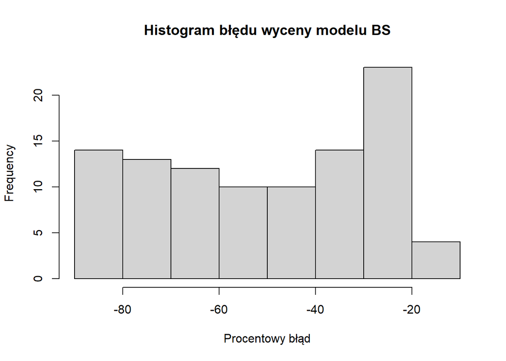

```r
hist(errors$estimate_error, main="Histogram błędu wyceny modelu BS", xlab="Procentowy błąd")
```

```r
n <- 100
ints <- rep(0,n)

for (alpha in c(0.01,0.05,0.1)){
  for (i in 1:n){
    ints[i] <- combine(N=1000, s=1064.7, r=0.0171, K=r$Strike[i], sigma=sigma, Ti=43/254,
              alpha =alpha)[2]
  }
  print(paste("Maksymalna wartość przedziału ufności dla alpha = ", alpha, " wynosi: ", max(ints)))
  print(paste("Minimalna wartość przedziału ufności dla alpha = ", alpha, " wynosi: ", min(ints)))
  print(paste("Średnia wartość przedziału ufności dla alpha = ", alpha, " wynosi: ", mean(ints)))

}
```

```
## [1] "Maksymalna wartość przedziału ufności dla alpha =  0.01  wynosi:  1.423275216017e-13"
## [1] "Minimalna wartość przedziału ufności dla alpha =  0.01  wynosi:  3.66823509282733e-17"
## [1] "Średnia wartość przedziału ufności dla alpha =  0.01  wynosi:  3.39185191975825e-14"
## [1] "Maksymalna wartość przedziału ufności dla alpha =  0.05  wynosi:  1.10019754291106e-13"
## [1] "Minimalna wartość przedziału ufności dla alpha =  0.05  wynosi:  1.67203273998641e-16"
## [1] "Średnia wartość przedziału ufności dla alpha =  0.05  wynosi:  2.90674531682937e-14"
## [1] "Maksymalna wartość przedziału ufności dla alpha =  0.1  wynosi:  9.22438851342978e-14"
## [1] "Minimalna wartość przedziału ufności dla alpha =  0.1  wynosi:  3.61420682401824e-16"
## [1] "Średnia wartość przedziału ufności dla alpha =  0.1  wynosi:  2.12895435905379e-14"
```

Jak widzimy, niezależnie od przyjętego poziomu ufności $\alpha$ te wartości przedziałów są bardzo niewielkie i w porównaniu do skali estymaty wręcz nieistotne. Oznacza to, że wyniki otrzymane z modelu mają niski próg dopuszczalnego błędu. Teraz sprawdźmy jeszcze na wykresie jak kształtują się rzeczywiście te wycenione ceny przez graczy oraz zamodelowane względem cen wykonania opcji dla pierwszych 30 obserwacji w celu zwiększenia czytelności.

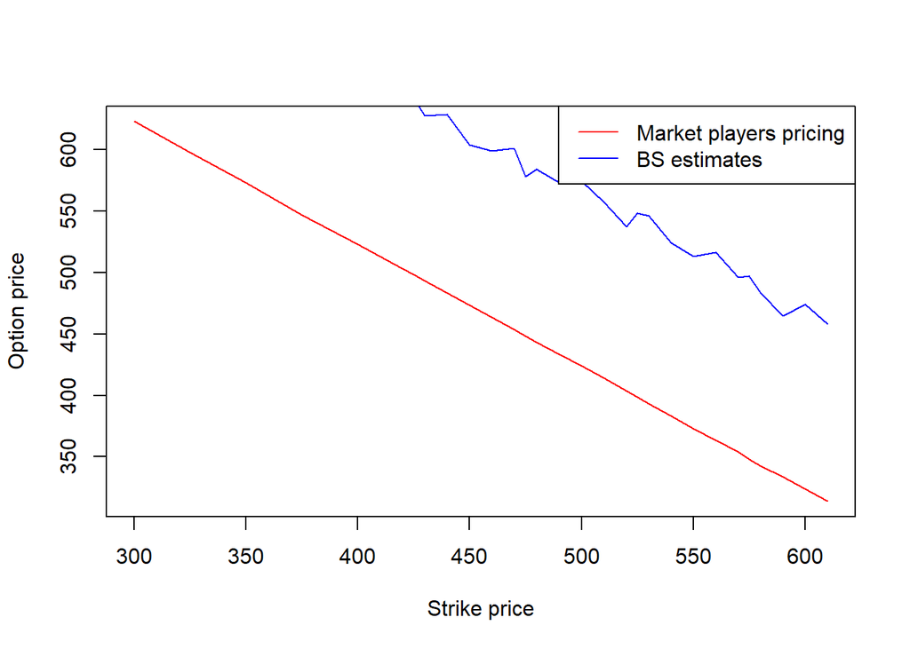

```r
plotting <- errors[1:30,]
plot(plotting$Strike, plotting$Ask, type = "l", col = "red", xlab="Strike price", ylab="Option price")
lines(plotting$Strike, plotting$estimates, type = "l", col ="blue")
legend(x = "topright", legend = c("Market players pricing", "BS estimates"), col=c("red","blue"),
       lty=1:1)
```

Sprawdźmy teraz sytuację, w której zaadaptowalibyśmy zmienność zastosowaną przez graczy giełdowych. Do poprzedniego kodu dodaję przekształcenie kolumny na numeryczną i dzielę przez procent. Przypomnijmy, że nasza obrana początkowa wartość wynosiła $\sigma = 56.78$%.

```r
n <- 100
estimates2 <- rep(0,n)
conf_intervals2 <- rep(0,n)

r['sigma2'] <- gsub("%","",r$Implied.Volatility)
r$sigma2 <- as.numeric(r$sigma2)/100

for (i in 1:n){
  res2 <- combine(N=1000, s=1064.7, r=0.0171, K=r$Strike[i], sigma=r$sigma2[i], Ti=43/254, alpha =0.05)

  estimates2[i] <- res2[1]
  conf_intervals2[i] <- res2[2]
}

errors2 <- cbind(r[1:100,], estimates2, conf_intervals2)
errors2['estimate_error'] <- ((errors2$Ask - errors2$estimates)/errors2$estimates)*100
summary(errors2$estimate_error)
```

```
##    Min. 1st Qu.  Median    Mean 3rd Qu.    Max.
##  -88.97  -72.28  -50.23  -51.87  -30.03  -19.19
```

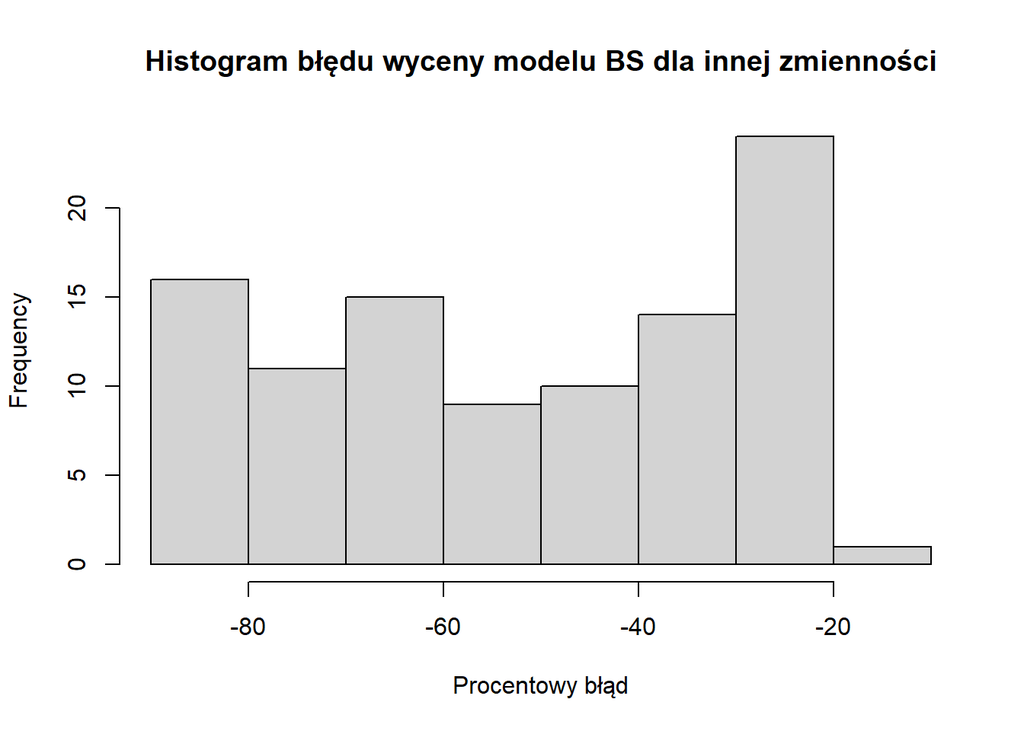

```r
hist(errors2$estimate_error ,main="Histogram błędu wyceny modelu BS dla innej zmienności", xlab="Procentowy błąd")
```

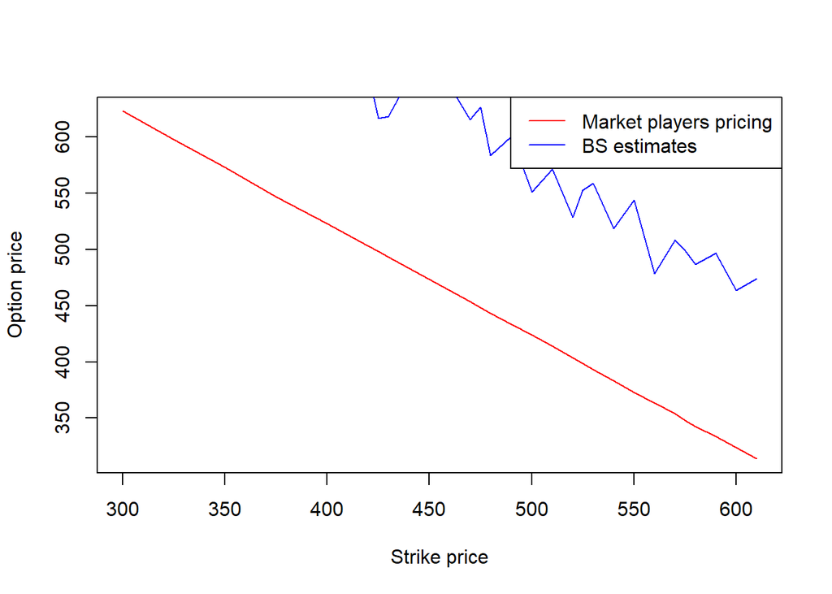

```r
plotting2 <- errors2[1:30,]
plot(plotting2$Strike, plotting2$Ask, type = "l", col = "red", xlab="Strike price", ylab="Option price")
lines(plotting2$Strike, plotting2$estimates, type = "l", col ="blue")
legend(x = "topright", legend = c("Market players pricing", "BS estimates"), col=c("red","blue"),
       lty=1:1)
```

Rzeczywiście widoczne są mocniejsze odchylenia. Ta zmienność daje nam poczucie w jakim stopniu przyszli gracze będą wyceniali opcje, jeśli są racjonalni. Z tego też względu występują owe, mocniejsze odchylenia. Zastosowana zmienność ze zbioru jest znacznie wyższa od tej obranej przez nas co ma wpływ na mocniejsze wahania.

Obierzmy teraz pierwszą cenę wykonania $K=300$ i przeanalizujmy pewne własności modelu BS przy tej wartości. W pierwszej kolejności sprawdźmy przebieg zmian wartości średniej wyceny przy rosnącym ciągu czasu $T$.

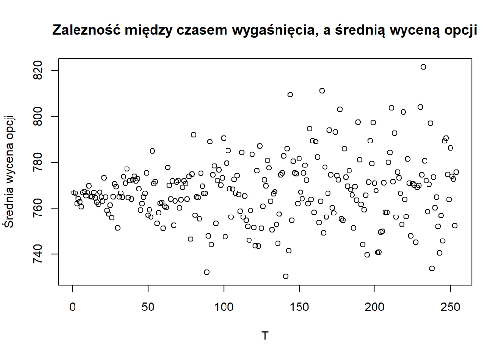

```r
E <- rep(0, 254)
Tn <- seq(1,254)
for (i in 1:254){
  E[i] <- combine(N=1000, s=1064.7, r=0.0171, K=300, sigma=sigma, Ti=i/254,
              alpha =alpha)[1]

}
plot(Tn, E, main="Zalezność między czasem wygaśnięcia, a średnią wyceną opcji", xlab="T", ylab="Średnia wycena opcji")
```

```r
print(paste("Średnie odchylenie standardowe od wyceny: ", sd(E)))
```

```
## [1] "Średnie odchylenie standardowe od wyceny:  14.0971063262165"
```

Możemy zauważyć, że wraz ze wzrostem czasu wygaśnięcia opcji nasze estymowane wyceny mają coraz to większy rozrzut. Świadczy to o trudności wyceny na przestrzeni dalekiego odcinka czasu. Nie jest to jednak zaskakujące, w przeciwnym wypadku wiele osób nie musiałoby już pracować. Tutaj rozpatrujemy przestrzeń jednego roku (254 dni giełdowe), jednak w dalszej perspektywie rozrzut ten z pewnością miałby o wiele wyższą wartość odchylenia standardowego, gdyż tutaj jest to kwestia zaledwie 15 USD.

## 4.6 Podsumowanie

Opcje są jednym z instrumentów finansowych, które dają posiadaczowi prawo do zakupu lub sprzedaży opcji. Są świetnym sposobem na zmniejszenie ryzyka przy zakupie aktywów. Przy pomocy modelu Blacka-Scholesa, który jest matematycznym modelem rynku opisującym dynamikę cen instrumentów finansowych w czasie, jesteśmy w stanie, dając odpowiednie informacje, zamodelować w pewien sposób wartość opcji dla danej (przykładowo) akcji poprzez wyznaczenie spodziewanego zysku z zakupu owej opcji.

Model Blacka-Scholesa jest często wykorzystywany do wyceny z racji swojej prostoty. Jednak posiada pewne założenia jak brak arbitrażu, brak ryzyka pożyczki i lokowania gotówki po tej samej stopie procentowej, brak kosztów transakcyjnych czy też brak wypłat dywidend, które są mało realistyczne. To powoduje, że w klasycznej postaci potrafi się spisać niezbyt dobrze w rynkowej rzeczywistości.

# Bibliografia

1.

Glasserman P (2004) Monte Carlo methods in financial engineering, Springer.

2.

Z. Amin JB K. Antonio (2020) Loss Data Analytics. An open text authored by the Actuarial Community (acessed 31-January-2022 from https://openacttexts.github.io/Loss-Data-Analytics/).

3.

Torino B (2020) Systematically Pricing Financial Options With Black Scholes (accessed 31-January-2022 from https://towardsdatascience.com/systematically-pricing-financial-options-with-black-scholes-4998c591ccbd).